# Estymacja przedziałowa

Beata Basiura  
październik 2023

### Zacznijmy od eksperymentu

- Testujemy czas wykonania programu wyznaczającego iloczyn dwóch macierzy kwadratowych z wykorzystaniem dwóch różnych technologi numerycznych :

  **1. bibliotek numerycznych C++**  
  **2. środowiska Scala JVM**
- Wyniki otrzymanych czasów z 25 eksperymentów zawarto w pliku **dane-czasy.csv** , a można je zaprezentować następująco:

### Otrzymane czasy

```
'data.frame':   50 obs. of  3 variables:
 $ wymiar: int  32 32 32 32 32 32 32 32 32 32 ...
 $ czasC : int  1241 1252 1253 1254 1260 1273 1290 1296 1320 1328 ...
 $ czasS : int  1146 1151 1162 1175 1194 1211 1228 1269 1270 1281 ...
```

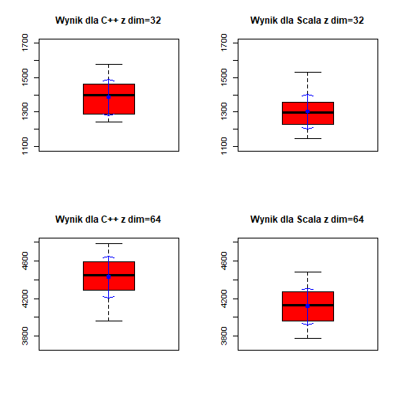

### Otrzymane czasy w ggplot2

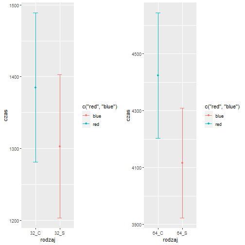

### Przedział ufności

**Definicja**

> **Przedziałem ufności** dla parametru θ na poziomie ufności 1 - α (poziomie istotności α), gdzie α ∈ (0,1) nazywa się taki przedział (θ<sub>1</sub>, θ<sub>2</sub>), którego końce są funkcjami próby losowej i nie zależą od szacowanego parametru θ  
> oraz P(θ<sub>1</sub>< θ < θ<sub>2</sub>) = 1 - α

Wyznaczony przedział (θ<sub>1</sub>, θ<sub>2</sub>) jest losowy (jest zmienną losową)  
**Źródło:** Hellwig Z.: Elementy rachunku prawdopodobieństwa i statystyki matematycznej. PWN, Warszawa 1998

### Przedział ufności dla średniej (1a)

- Dla **wartości przeciętnej**
- Przy małej próbie ( n<30 )
- Przy **nieznanym** odchyleniu standardowym σ
- Przy poziomie ufności 1 - α

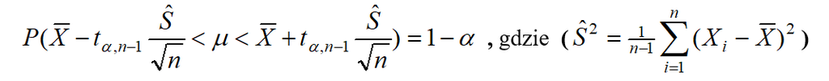

### Przedział ufności dla średniej (1b)

**Zadanie 1**  
Wyznaczyć przedział ufności czasu wykonania programu na poziomie ufności 1 - α = 0.98

```r
czas <-c(1241,1252,1253,1254,1260,1273,1290,1296,1320, 1328,1334,1351,1400,1434,1447,1450, 1456,1461,1461,1464,1480,1500,1520,1525,1575)
n <- length(czas)
# Średnia :
m<-mean(czas)
# Odchylenie standard. z próby :
s<-sd(czas)
# Kwantyl rozkładu t-Studenta na podstawie wartości alfa:
alfa = 1-0.98;  e<-qt(1-alfa/2,n-1)
# Margines błędu :
E<-e*s/sqrt(n)
# Przedział ufności :
m+c(-E,+E)
```

```
[1] 1333.215 1436.785
```

### Przedział ufności dla średniej (1c)

**Przelicz samodzielnie**  
**Zadanie 2**  
Przeliczyć zadanie poprzednie dla danych:  
czas<-c(1146,1151,1162,1175,1194,1211,1228,1269,1270,1281,1281,1293, 1296,1311,1324,1330,1338,1343,1355,1397,1405,1420,1432,1436,1531)

### Przedział ufności dla średniej (2a)

- Dla **wartości przeciętnej**
- Przy **znanym** odchyleniu standardowym **sigma**
- Przy poziomie **istotności** α

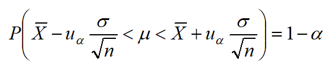

### Przedział ufności dla średniej (2b)

**Zadanie 3**  
Na podstawie 64 losowo wybranych rozmów telefonicznych obliczono średnią długość rozmowy, która wyniosła 4,2 minuty. Z poprzednich badań wiadomo, że wariancja długości rozmów telefonicznych wynosi 1,44 minuty<sup>2</sup>.  
Zakładając, że czas rozmów ma rozkład normalny oszacować przedziałowo średnią długość rozmowy telefonicznej na poziomie ufności 0,95.

```r
n <- 64
m <- 4.2
sigma <- sqrt(1.44)
# Kwantyl rozkładu Normalego ;
alfa = 0.05; e<-qnorm(1-alfa/2)
# Margines błędu :
E<-e*sigma/sqrt(n)
# Przedział ufności :
m+c(-E,+E)
```

```
[1] 3.906005 4.493995
```

### Przedział ufności dla średniej (2c)

**Przelicz samodzielnie**  
**Zadanie 4**  
dla 1 - α = 0.99

Wniosek:

> Im przedział ma większą dokładność (bliżej 100%) tym jest **?? szerszy ?? węższy ??** …

### Przedział ufności dla średniej (3a)

- Dla **wartości przeciętnej**
- Przy dużej próbie (n>50)
- Przy nieznanym odchyleniu standardowym **σ**
- Przy poziomie istotności α

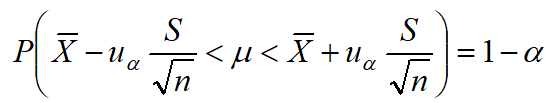

### Przedział ufności dla średniej (3b)

**Zadanie 5**  
Wyzancz przedział ufności dla średniej ceny ręcznika bawełnianego przyjmując poziom istotności α = 0.05.

```r
dane<-read.csv("dane-ceny.csv")
head(dane$recznikibawelniane)
```

```
[1] 21.25 18.85 21.49 21.24 18.61 20.89
```

```r
#"Długość próby :
n<-dim(dane)[1]
#Średnia :
m.cena<-mean(dane$recznikibawelniane,na.rm=T)
#Odchylenie standard. : z próby :
s<-sd(dane$recznikibawelniane)
#Kwantyl rozkładu Normalego : alfa = 0.05
alfa = 0.05;e<-qnorm(1-alfa/2)
#Margines błędu :
E<-e*s/sqrt(n)
#Przedział ufności :
m.cena+c(-E,+E)
```

```
[1] 20.4881 20.9019
```

### Przedział ufności dla średniej (3c)

**Przelicz samodzielnie**  
**Zadanie 6**  
Przelicz poprzednie zadanie dla alfa = 0.1 oraz cen fileta z morszczuka

### Przedział ufności dla frakcji (1)

> **Przedział ufności dla frakcji** (odsetka) to szacowany z prawdopodobiństwem 1-α przedział, w którym znajduje się szukana frakcja(odsetek), czyli procent populacji, który spełnia zadany warunek.

Jest wyznaczany według podanego wzoru  
(Uwaga: tylko dla dużej próby n>100)

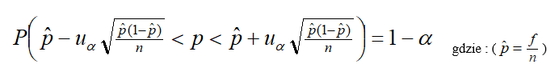

### Przedział ufności dla frakcji (2)

Dla **frakcji** przy dużej próbie (n>100)  
**Zadanie 7** :  
Wśród 694 kobiet pracujących w IT 222 odpowiedziało, że współpracuje wyłącznie z mężczyznami. Jaki jest przedział ufności udziału kobiet współpracujących wyłącznie z mężczyznami? Przyjmij poziom istotności alfa = 0.1

```r
#Liczba badanych kobiet
n<-694
# liczba kobiet współpracujących z mężczyznami
k<-222
# Frakcja : f <- k/n
(f <- k/n)
```

```
[1] 0.3198847
```

```r
# Błąd
(SE <- sqrt(f*(1-f)/n))
```

```
[1] 0.0177055
```

```r
#Margines błędu :
( E<-qnorm(1-0.1/2)*SE)
```

```
[1] 0.02912296
```

```r
#Przedział ufności
(f+c(-E,+E))
```

```
[1] 0.2907618 0.3490077
```

### Przedział ufności dla frakcji (3)

Dla **frakcji** przy dużej próbie (n>100)  
**Przelicz samodzielnie**  
**Zadanie 8**  
Wśród 649 kobiet pracujących w IT 472 odpowiedziało, że pracuje w grupach mieszanych. Jaki jest przedział ufności udziału kobiet pracujących w grupach mieszanych? Przyjmij poziom istotności α = 0.05 .

### Minimalna liczebność próby (1)

**Minimalna liczebność próby** to wielkość określająca ile danych potrzeba, aby maksymalny błąd oszacowania (na poziomie ufności 1–α ) wyniósł co najwyżej **d**.  
Im więcej badanych obserwacji jest rozważanych tym szacowanie jest bardziej dokładne przez co otrzymany przedział ufności będzie węższy. Jednakże z powodu kosztowności pomiarów możliwości powiększania ilości obserwacji są ograniczone. Zatem rozsądnym wydaje się znalezienie **złotego środka** między **dokładnością, a ilością obserwacji**. Należy zwrócić uwagę na typ rozważanego zagadnienia.

### Minimalna liczebność próby (2a)

- Dla wartości średniej
- Przy znanym odchyleniu standardowym σ
- Przy dopuszczalnym, ustalonym z góry, maksymalnym **błędzie szacunku** *d*

**Uwaga**: Jeżeli obliczona liczebność próby **n** jest mniejsza od liczebności próby wstępnej to wstępna liczebność jest wystarczająca, w przeciwnym przypadku próbę należy zwiększyć do wymaganych **n** elementów.

### Minimalna liczebność próby (2b)

**Zadanie 9**  
Wróćmy do zadania 5 o średniej cenie recznika bawaełnianego. Wyznacz minimalną liczebność próby dla średniej ceny, przyjmując, że:

- σ = 1.05
- d = 0.2
- α = 0.05

```r
# Długość próby :
n<-length(dane$recznikibawelniane)
# Wartość średniej :
m.cena<-mean(dane$recznikibawelniane)
# Zane (z innych badań) odchylenie standardowe :
sigma <- 1.05
# Wartość przyjętego błędu :
d <- 0.2
# Kwantyl rozkładu Normalego :
alfa <- 0.05 ; e<-qnorm(1-alfa/2)
# Wyznaczona liczebność :
(licz<- e^2*sigma^2/d^2); (n)
```

```
[1] 105.8802
```

```
[1] 108
```

### Minimalna liczebność próby (3a)

- Dla wartości średniej
- Przy nieznanym odchyleniu standardowym
- Przy dopuszczalnym, ustalonym z góry, maksymalnym **błędzie szacunku** *d*

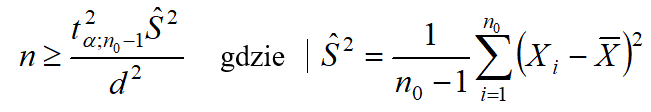

**Uwaga**: Jeżeli obliczona liczebność próby **n** jest mniejsza od liczebności próby wstępnej to wstępna liczebność jest wystarczająca, w przeciwnym przypadku próbę należy zwiększyć do wymaganych **n** elementów.

### Minimalna liczebność próby (3b)

**Zadanie 10**  
Wróćmy do zadania 5 o średniej cenie ręcznika bawełnianego. Wyznacz minimalną liczebność próby dla średniej ceny, przyjmując, że nie znamy odchylenia standardowego oraz

- d = 0.3
- α = 0.05

```r
# Długość próby :
n<-length(dane$recznikibawelniane)
# Wartość średnia :
m.cena<-mean(dane$recznikibawelniane)
# Wartość odchylenia standardowego (nieznana - wyznaczona z próby):
s<-sd(dane$recznikibawelniane,na.rm=TRUE)
# Błąd :
d <- 0.3
# Kwantyl rozkładu t-Studenta :
e<-qt(1-0.05/2,df=n-1)
# Wyznaczona liczność :
(licz<- e^2*s^2/(d^2)); n
```

```
[1] 52.5523
```

```
[1] 108
```

### Minimalna liczebność próby (4a)

- Dla frakcji
- Przy znanym **z próby** *f*
- Przy dopuszczalnym, ustalonym z góry, maksymalnym **błędzie szacunku** *d*

**Uwaga**: Jeżeli obliczona liczebność próby **n** jest mniejsza od liczebności próby wstępnej to wstępna liczebność jest wystarczająca, w przeciwnym przypadku próbę należy zwiększyć do wymaganych **n** elementów.

### Minimalna liczebność próby (4b)

**Zadanie 11**  
Wróćmy do **zadania 7** o udziale kobiet współpracujących wyłącznie z mężczyznami. Czy liczebność na poziomie 694 jest wystarczająca?  
Zakładamy, że α = 0.01 natomiast dopuszczalny błąd d = 0.06 .

```r
# Liczba badanych kobiet :
n <-694
# Liczba kobiet pracujących wyłącznie z mężczyznami
k<- 222
# Szacowana frakcja :
(f <- k/n)
```

```
[1] 0.3198847
```

```r
# Przyjęty błąd :
d <- 0.06
# Kwantyl rozkładu Normalnego :
alfa <- 0.01 ; e<-qnorm(1-alfa/2)
# Wymagana liczebność :
(licz<-e^2*f*(1-f)/d^2)
```

```
[1] 400.9661
```

### Minimalna liczebność próby (5a)

- Dla frakcji
- Przy nieznanym *f*
- Prz dopuszczalnym, ustalonym z góry, maksymalnym **błędzie szacunku** *d*

**Uwaga**: Jeżeli obliczona liczebność próby **n** jest mniejsza od liczebności próby wstępnej to wstępna liczebność jest wystarczająca, w przeciwnym przypadku próbę należy zwiększyć do wymaganych **n** elementów.

### Minimalna liczebność próby (5b)

**Zadanie 12**  
Ile osób należy wylosować populacji, aby poprawnie zweryfikować ile wynosi frakcja osób z grupą krwi B. Zakładamy poziom istotności α = 0.05 natomiast dopuszczalny błąd d = 0.045.

```r
# Założony błąd :
d <- 0.045
# Kwantyl rozkładu Normalnego :
alfa <- 0.05; e<-qnorm(1-alfa/2)
# Wyznaczona liczebność :
(licz<-e^2/(4*d^2))
```

```
[1] 474.2542
```

### Minimalna liczebność próby (6)

**Przelicz samodzielnie**  
**Zadanie 13**  
Dane **survey** z biblioteki MASS dotyczą wzrostu studentów Uniwersytetu w Adelaide. Wyznacz minimalną liczebność próby dla udziału kobiet (frakcji kobiet) wśród badanych studentów.

```r
library(MASS)
data(survey)
head(survey[,c(1,10)])
```

```
     Sex Height
1 Female 173.00
2   Male 177.80
3   Male     NA
4   Male 160.00
5   Male 165.00
6 Female 172.72
```

```r
table(survey$Sex)
```

```
Female   Male
   118    118
```

### Podsumowanie

**Liczyliśmy** :

1. Przedział ufności dla średniej (3 różne modele)
2. Przedział ufności dla frakcji (duża próba)
3. Minimalną liczebność próby dla średniej (dwa przypadki)
4. Minimalną liczebność próby dla frakcji (dwa przypadki)